# Data Analysis - Exercise Sheet 1

# 4. Visualizing data distribution

In this section you will learn the essential functions to plot data in an intuitive and useful way.

### Histograms

We can plot the column “stab.glu” as a histogram using the `hist()` function:

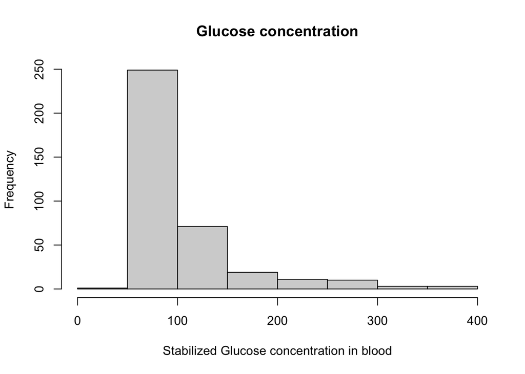

```r
hist(dat$stab.glu, xlab = "Stabilized Glucose concentration in blood", main = "Glucose concentration")
```

Remember that you can type `help("hist")` in the Console to see more details about the histogram function in R.

> Add the parameter `breaks = 50` in the above lines of code and see what happens. Try different values for `breaks` like `10, 20, 75, 100` and try to interpret the differences. Is this a good or bad thing about histograms in general?

### Density plots

For density plots, we use the `density()` function to estimate the probability density function for a given variable. With its return value, we can build the final density plot using the `plot()` function:

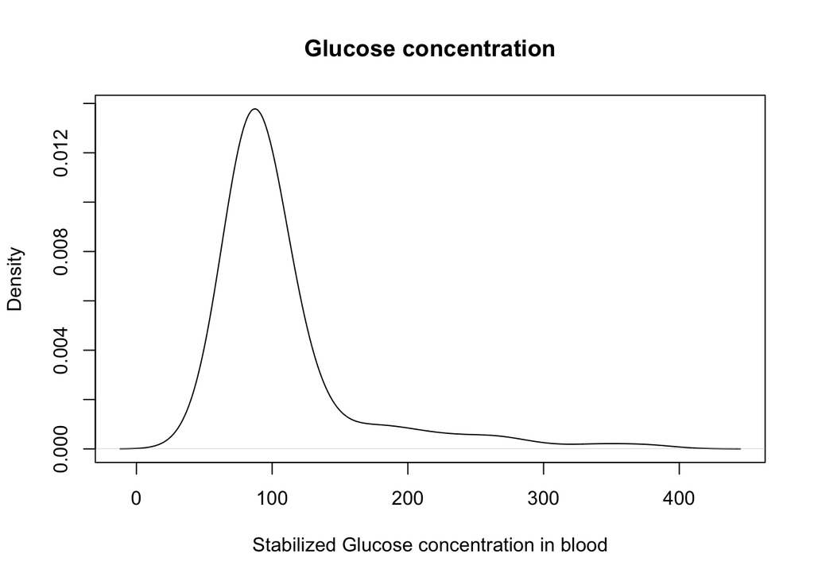

```r
d <- density(dat$stab.glu, bw = 20)
plot(d, xlab = "Stabilized Glucose concentration in blood", main = "Glucose concentration")
```

> Change the value of `bw` and see how the plot changes

### Boxplots

The `boxplot()` function produces a boxplot for a given variable:

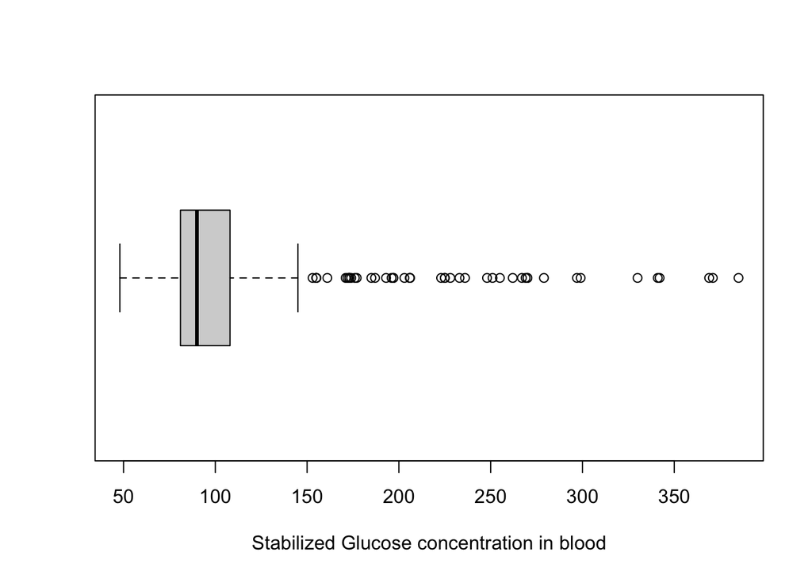

```r
boxplot(dat$stab.glu, xlab = "Stabilized Glucose concentration in blood", horizontal = TRUE)
```

> Can you explain all features of this graph, such as upper/lower whisker, 25% quantile, …?

### QQ-plots

As discussed in the lecture, we can use **QQ-plots** to either (1) compare two distributions, or (2) compare a distribution with a theoretical distribution (typically the normal distribution).

We can for example compare the distribution of the blood pressure values to check if they are normally distributed

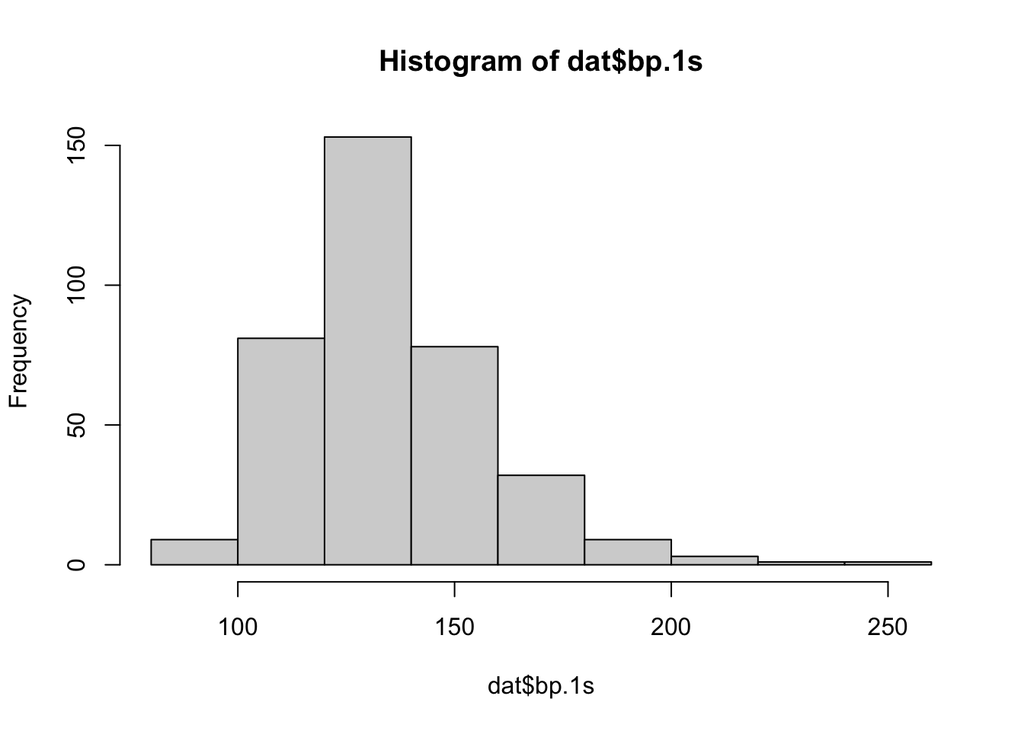

```r
## Let's first make a histogram
hist(dat$bp.1s)
```

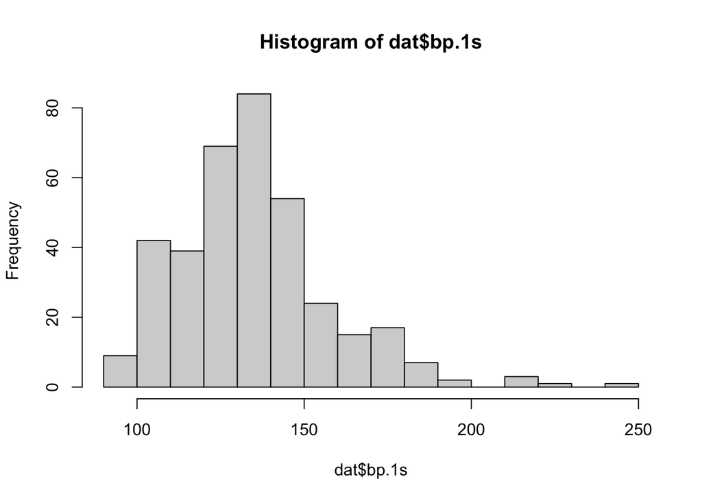

```r
## Maybe with more bins?
hist(dat$bp.1s, breaks = 20)
```

Now we can use the function `qqnorm()` to generate the **QQ-plot** of this distribution against the standard normal distribution:

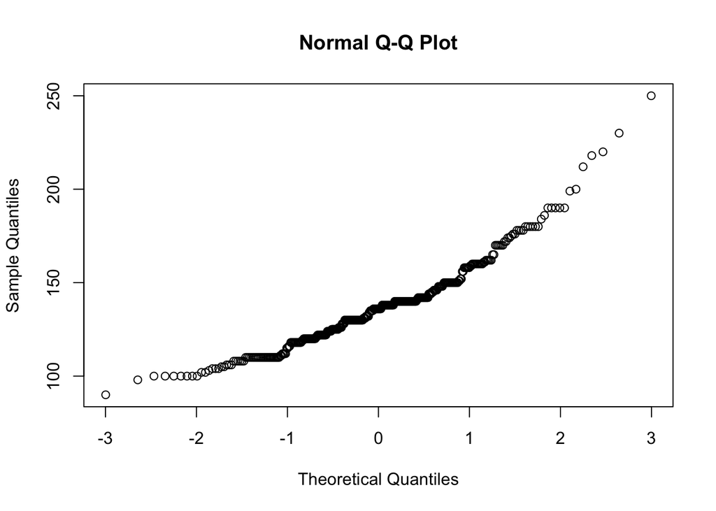

```r
qqnorm(dat$bp.1s)
```

Using the additional command `qqline()`, we can add a straight line that goes through the first and third quartile:

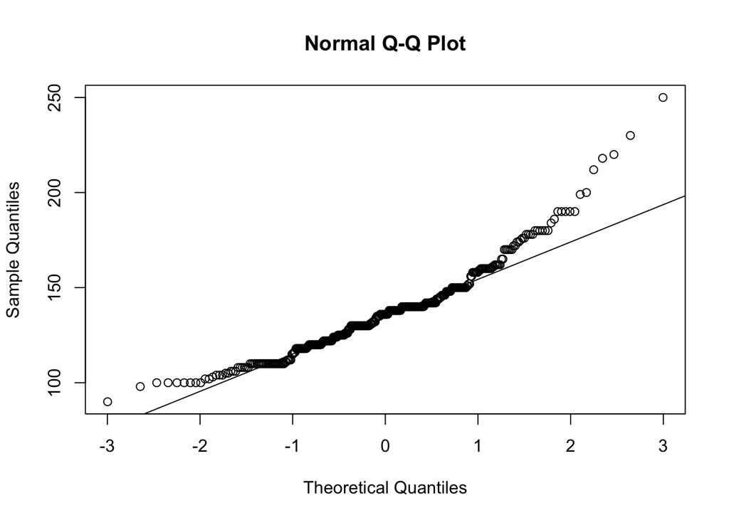

```r
qqnorm(dat$bp.1s)
qqline(dat$bp.1s)
```

> So, is the distribution normal??

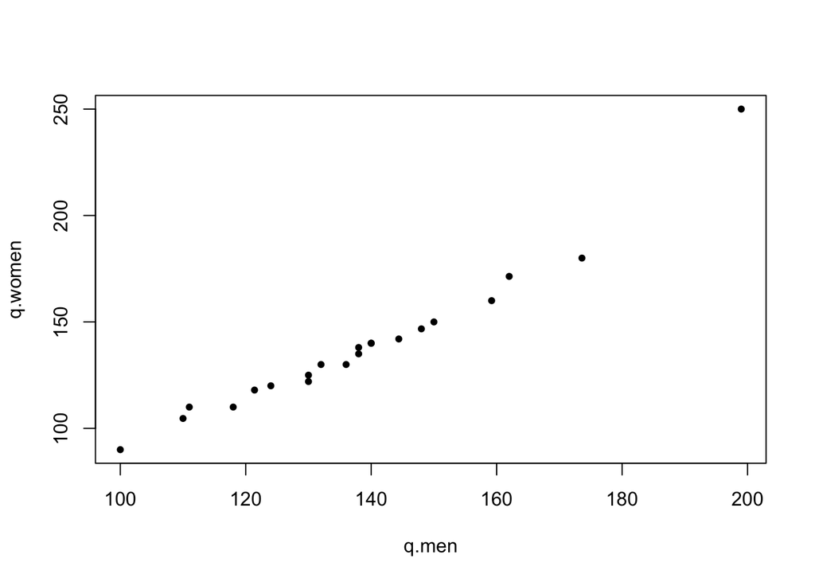

```r
# We can use 'which()' to select the cholesterol values for men and women

rows.men = which(dat$gender == "male")  # positions of male patients
rows.women = which(dat$gender == "female")

bp.men = dat$bp.1s[rows.men]  # select all values from the 'bp.1s' column that correspond to male patients
bp.women = dat$bp.1s[rows.women]

# Compute the quantiles (note the 'na.rm' option to ignore missing NA values!)
q.men = quantile(bp.men, probs = seq(0, 1, by = 0.05), na.rm = TRUE)
q.women = quantile(bp.women, probs = seq(0, 1, by = 0.05), na.rm = TRUE)

# Now plot against each other!
plot(q.men, q.women, pch = 20)
```

# 5. Exercises

### Exercise 1: Data Exploration and Summary Statistics

The summary() function gives us a quick overview, but sometimes we need more specific information.

1. Calculate the mean and standard deviation of the hdl (High Density Lipoprotein) values for the entire dataset using `mean()` and `sd()`.
2. Create a new variable called `bmi` (Body Mass Index) in the dataset using the formula: BMI = weight (in pounds) / height^2 (in inches) × 703. Add this as a new column to `dat`.
3. Use the `table()` function to count how many patients come from each location. Which location has the most patients?
4. Calculate the median age separately for male and female patients. Are they similar?

### Exercise 2: Visualizing Relationships Between Variables

In this exercise, you’ll explore relationships between different clinical measurements.

1. Create a scatter plot of `weight` vs `height` using the `plot()` function. Do you see a relationship between these variables?
2. Use the `cor()` function to calculate the correlation coefficient between weight and height. How strong is this relationship?
3. Create side-by-side boxplots comparing cholesterol levels (`chol`) between males and females using `boxplot(chol ~ gender, data = dat)`. What differences do you observe? Try with other variables!
4. Color the points in your scatter plot from question 1 by gender using the `col` parameter. *Hint: you can use `col = as.numeric(as.factor(dat$gender))`*. Does the relationship between weight and height appear different for men and women?

### Going further: Advanced Data Manipulation (for advanced students)

1. Create a categorical variable called `age_group` that divides patients into three categories: “young” (age < 40), “middle” (40 ≤ age < 60), and “senior” (age ≥ 60). Add this as a new column to `dat`. *Hint: use nested `ifelse()`statements or the `cut()` function*.
2. Calculate the mean cholesterol level for each combination of `gender` and `age_group`. Store these results in a matrix or data frame. *Hint: you can use `tapply()` or a combination of subsetting with `which()` and `mean()`*.
3. Create a function called `standardize()` that takes a numeric vector as input and returns a z-transformed version (subtract mean, divide by standard deviation). Apply this function to all numerical columns in `dat` to create a standardized version of the dataset called `dat.scaled`. *Hint: you can use `apply()` with `MARGIN = 2` for columns, but remember to skip non-numeric columns*.
4. Using your standardized dataset, identify which patient has the most extreme (highest or lowest) standardized BMI value. Print out all their clinical information. What makes this patient unusual?